# IODS course project

# Logistic regression

This is the third chapter including logistic regression analysis.

First, I read the data from URL and explored basic structure and dimensions

```r
# access the tidyverse libraries tidyr, dplyr, ggplot2
library(tidyr); library(dplyr); library(ggplot2)

# Read data from URL

alc <- read.table("http://s3.amazonaws.com/assets.datacamp.com/production/course_2218/datasets/alc.txt", sep=",", header=TRUE)

str(alc)
```

```
## 'data.frame':    382 obs. of  35 variables:
##  $ school    : Factor w/ 2 levels "GP","MS": 1 1 1 1 1 1 1 1 1 1 ...
##  $ sex       : Factor w/ 2 levels "F","M": 1 1 1 1 1 2 2 1 2 2 ...
##  $ age       : int  18 17 15 15 16 16 16 17 15 15 ...
##  $ address   : Factor w/ 2 levels "R","U": 2 2 2 2 2 2 2 2 2 2 ...
##  $ famsize   : Factor w/ 2 levels "GT3","LE3": 1 1 2 1 1 2 2 1 2 1 ...
##  $ Pstatus   : Factor w/ 2 levels "A","T": 1 2 2 2 2 2 2 1 1 2 ...
##  $ Medu      : int  4 1 1 4 3 4 2 4 3 3 ...
##  $ Fedu      : int  4 1 1 2 3 3 2 4 2 4 ...
##  $ Mjob      : Factor w/ 5 levels "at_home","health",..: 1 1 1 2 3 4 3 3 4 3 ...
##  $ Fjob      : Factor w/ 5 levels "at_home","health",..: 5 3 3 4 3 3 3 5 3 3 ...
##  $ reason    : Factor w/ 4 levels "course","home",..: 1 1 3 2 2 4 2 2 2 2 ...
##  $ nursery   : Factor w/ 2 levels "no","yes": 2 1 2 2 2 2 2 2 2 2 ...
##  $ internet  : Factor w/ 2 levels "no","yes": 1 2 2 2 1 2 2 1 2 2 ...
##  $ guardian  : Factor w/ 3 levels "father","mother",..: 2 1 2 2 1 2 2 2 2 2 ...
```

[output cut: 21 more lines]

```r
dim(alc)
```

```
## [1] 382  35
```

The data has 382 rows and 35 variables Variables are integers, factors and one is boolean statement

Next, I visualized variables. Graph shows that most of the students don’t belong in to high use category

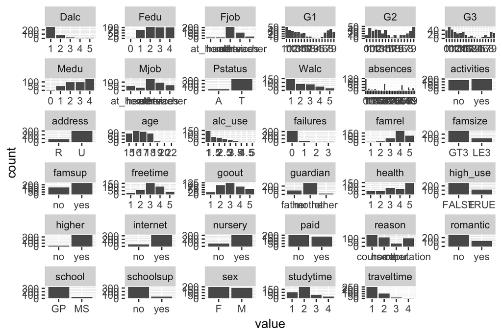

```r
# draw a bar plot of each variable
gather(alc) %>% ggplot(aes(value)) + facet_wrap("key", scales = "free") + geom_bar()
```

For logistic regression analysis I chose sex, age, romantic and absences My hypoteses is that young single men with a lot of absences have high probability to high use of alcohol This hypoteses is build on real life experience, not scientific articles :)

```r
# find the model with glm()
m <- glm(high_use ~ sex + age + romantic + absences, data = alc, family = "binomial")

# compute odds ratios (OR)
OR <- coef(m) %>% exp

# print out a summary of the model
summary(m)
```

```
##
## Call:
## glm(formula = high_use ~ sex + age + romantic + absences, family = "binomial",
##     data = alc)
##
## Deviance Residuals:
##     Min       1Q   Median       3Q      Max
## -2.7179  -0.8456  -0.6286   1.0823   2.1893
##
## Coefficients:
##             Estimate Std. Error z value Pr(>|z|)
## (Intercept) -4.54258    1.70433  -2.665  0.00769 **
## sexM         0.99159    0.24303   4.080 4.50e-05 ***
## age          0.16915    0.10226   1.654  0.09810 .
## romanticyes -0.29584    0.26585  -1.113  0.26579
## absences     0.07283    0.01828   3.983 6.79e-05 ***
## ---
## Signif. codes:  0 '***' 0.001 '**' 0.01 '*' 0.05 '.' 0.1 ' ' 1
##
## (Dispersion parameter for binomial family taken to be 1)
##
##     Null deviance: 462.21  on 381  degrees of freedom
## Residual deviance: 422.16  on 377  degrees of freedom
## AIC: 432.16
##
## Number of Fisher Scoring iterations: 4
```

```r
# print out the coefficients of the model
coef(m)
```

```
## (Intercept)        sexM         age romanticyes    absences
## -4.54258123  0.99158774  0.16915207 -0.29584023  0.07282766
```

```r
# compute confidence intervals (CI)
CI <- confint(m) %>% exp
# print out the odds ratios with their confidence intervals
cbind(OR, CI)
```

```
##                     OR        2.5 %   97.5 %
## (Intercept) 0.01064589 0.0003570945 0.290015
## sexM        2.69551085 1.6842578252 4.375275
## age         1.18430022 0.9701859445 1.450229
## romanticyes 0.74390627 0.4371001910 1.242806
## absences    1.07554516 1.0398995842 1.116863
```

Based on logistic regression analysis, the hypoteses seems to be partially correct.

Men seems to have much higher probability of belonging to heavy users than women. Their Odds Ratio is 2.7. However, the confidence interval is wide (1.7-4.4) which means that the probability can be much smaller or higher. The result is also statistically significant.

Romantic relationship seems to lower the probability of high use as in hypoteses. Odds ratio is 0.74 when in a relationship. However, it’s not statistically significant, so we can’t make these conclusions.

Age and absences don’t have large impact on probabality of high use. Absences are statistically significant, age is not. Therefore, we can conclude that high number of absences slightly increase the probability of belonging to high users.

The last thing is to check the accuracy of predictions

```r
# fit the model
m <- glm(high_use ~ sex + absences, data = alc, family = "binomial")

# predict() the probability of high_use
probabilities <- predict(m, type = "response")

# add the predicted probabilities to 'alc'
alc <- mutate(alc, probability = probabilities)

# use the probabilities to make a prediction of high_use
alc <- mutate(alc, prediction = probability > 0.5)

# tabulate the target variable versus the predictions
table(high_use = alc$high_use, prediction = alc$prediction)
```

```
##         prediction
## high_use FALSE TRUE
##    FALSE   263    7
##    TRUE     89   23
```

```r
# define a loss function (mean prediction error)
loss_func <- function(class, prob) {
  n_wrong <- abs(class - prob) > 0.5
  mean(n_wrong)
}

# call loss_func to compute the average number of wrong predictions in the (training) data
loss_func(class = alc$high_use, prob = alc$probability)
```

```
## [1] 0.2513089
```